# Mapas de relieve de Portugal y camas hospitalarias en Europa

Proyecto 2 · Visualización geoespacial

Author

Carla Daniela Di Monno

## Primera parte: hillshade de Portugal

El *hillshade* es un mapa de relieve con efectos de sombra que genera profundidad visual. La zona elegida es Portugal, el país en el que resido.

Los datos se preparan una sola vez con `scripts/fetch_ag3_data.R` y se guardan en `data/processed/`. Así el informe se renderiza sin descargas repetidas.

```r
ruta_lagos <- here("data", "processed", "lagos_portugal.rds")
ruta_mdt <- here("data", "processed", "mdt_portugal.tif")

if (!file.exists(ruta_lagos) || !file.exists(ruta_mdt)) {
  stop("Faltan datos. Ejecuta: Rscript scripts/fetch_ag3_data.R", call. = FALSE)
}

pt_lakes <- read_rds(ruta_lagos)
mdt_r <- rast(ruta_mdt)
names(mdt_r) <- "alt"

pt <- gisco_get_countries(country = "Portugal", resolution = "03") %>%
  st_transform(st_crs(pt_lakes))

glimpse(pt_lakes)
```

```
Rows: 16
Columns: 6
$ idhidro    <dbl> 69000464, 69000465, 69000458, 69000461, 69000454, 69000460,…
$ nome       <chr> "Lagoa das Braças", "Lagoa de Teixoeiros", "Lagoa Óbidos", …
$ diplegal   <chr> "DLei 107/2009", "DLei 107/2009", "DLei 107/2009", "DLei 10…
$ st_area_sh <dbl> 278682.9, 106717.3, 6552976.8, 586038.5, 549813.3, 214052.8…
$ st_length_ <dbl> 2428.750, 1539.337, 26703.542, 5763.550, 5343.766, 1884.158…
$ geometry   <MULTIPOLYGON [m]> MULTIPOLYGON (((-57146.88 6..., MULTIPOLYGON (…
```

### Límites de los lagos

Los límites proceden del Sistema Nacional de Información Geográfica de Portugal (SNIG), concretamente la capa de lagos y lagunas de dominio público de Portugal Continental.

```r
pt_lakes <- pt_lakes %>%
  mutate(areakm = set_units(st_area(geometry), "km^2"))

pt_lakes %>%
  st_drop_geometry() %>%
  select(areakm) %>%
  summary()
```

```
     areakm
 Min.   :0.1067
 1st Qu.:0.2635
 Median :0.6435
 Mean   :1.5510
 3rd Qu.:1.3577
 Max.   :6.5530
```

### Modelo digital del terreno

El MDT se descarga con `elevatr` y se agrega para reducir el consumo de memoria. Se trabaja directamente con `SpatRaster`, evitando convertirlo a un data.frame y los avisos de píxeles irregularmente espaciados.

```r
dim(mdt_r)
```

```
[1] 2653 3984    1
```

```r
res(mdt_r)
```

```
[1] 621.8335 621.8335
```

```r
ncell(mdt_r)
```

```
[1] 10569552
```

```r
ALT_BREAKS <- c(0, 200, 500, 1000, 1500, 2000, 2500)
```

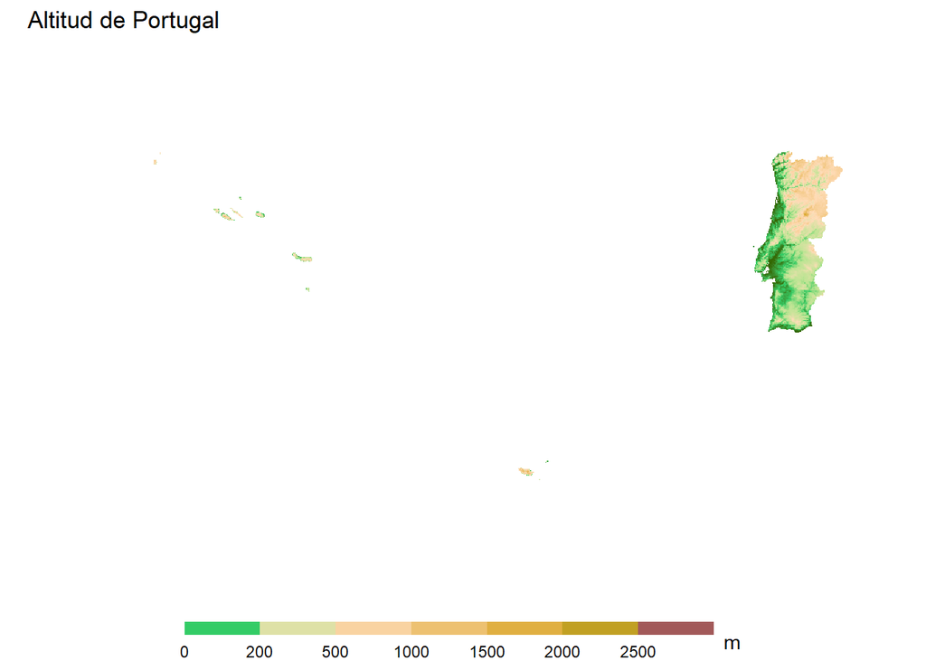

```r
ggplot() +
  geom_spatraster(data = mdt_r, aes(fill = alt)) +
  scale_fill_hypso_tint_c(breaks = ALT_BREAKS) +
  geom_sf(data = pt_lakes, fill = "#c6dbef", colour = NA) +
  guides(fill = guide_colorsteps(barwidth = 20, barheight = .5,
                                 title.position = "right")) +
  labs(fill = "m", title = "Altitud de Portugal") +
  coord_sf() +
  theme_void() +
  theme(legend.position = "bottom")
```

### Calcular el hillshade

Se estiman pendiente y orientación en radianes y se aplica `terra::shade()` con 30º de elevación.

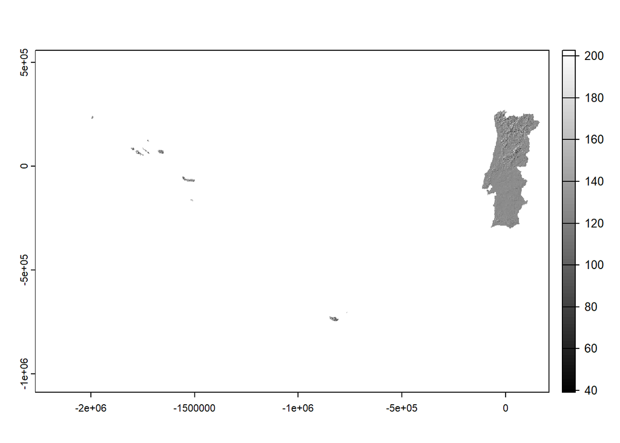

```r
sl <- terrain(mdt_r, "slope", unit = "radians")
asp <- terrain(mdt_r, "aspect", unit = "radians")

hill_single <- shade(sl, asp, angle = 30, direction = 300, normalize = TRUE)
names(hill_single) <- "hillshade"

plot(hill_single, col = grey(1:100 / 100))
```

### Función de mapa reutilizable

En lugar de repetir el mismo código para cada variante, se define una única función que combina el sombreado, la altitud y los lagos.

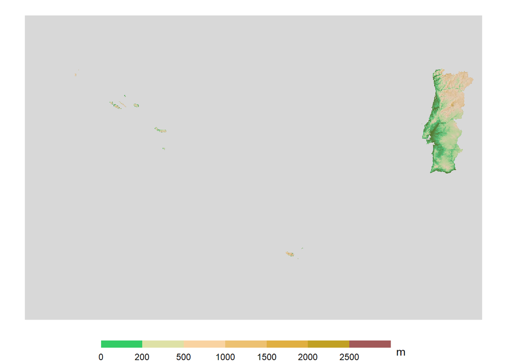

```r
make_relief_map <- function(hill, layer = "hillshade",
                            legend = "bottom",
                            alpha_alt = .7) {
  names(hill) <- layer

  ggplot() +
    geom_spatraster(data = hill, aes(fill = .data[[layer]]),
                    show.legend = FALSE) +
    scale_fill_distiller(palette = "Greys") +
    new_scale_fill() +
    geom_spatraster(data = mdt_r, aes(fill = alt), alpha = alpha_alt) +
    scale_fill_hypso_tint_c(breaks = ALT_BREAKS) +
    geom_sf(data = pt_lakes, fill = "#c6dbef", colour = NA) +
    guides(fill = guide_colorsteps(barwidth = 20, barheight = .5,
                                   title.position = "right")) +
    labs(fill = "m") +
    coord_sf() +
    theme_void() +
    theme(legend.position = legend)
}

make_relief_map(hill_single, legend = "bottom")
```

### Sombras multidireccionales

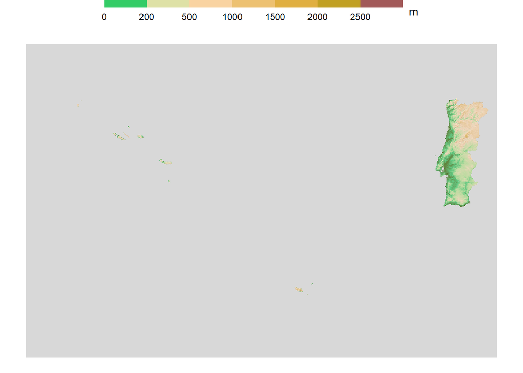

```r
hillmulti <- map(c(270, 15, 60, 330), function(dir) {
  shade(sl, asp, angle = 30, direction = dir, normalize = TRUE)
}) %>%
  rast() %>%
  sum()

names(hillmulti) <- "hillshade"

make_relief_map(hillmulti, legend = "top")
```

### Comparación con mezcla de capas

[figure not shown]

```r
mapa_blend <- ggplot() +
  list(
    geom_spatraster(data = hillmulti, aes(fill = hillshade),
                    show.legend = FALSE),
    scale_fill_distiller(palette = "Greys"),
    new_scale_fill(),
    geom_spatraster(data = mdt_r, aes(fill = alt), alpha = .7),
    scale_fill_hypso_tint_c(breaks = ALT_BREAKS)
  ) %>%
  ggblend::blend("multiply") +
  geom_sf(data = pt_lakes, fill = "#c6dbef", colour = NA) +
  guides(fill = guide_colorsteps(barwidth = 20, barheight = .5,
                                 title.position = "right")) +
  labs(fill = "m") +
  coord_sf() +
  theme_void() +
  theme(legend.position = "top")

mapa_blend
```

### Alternativa con WhiteboxTools

WhiteboxTools ofrece una implementación propia de hillshade multidireccional. La instalación del binario solo se hace si no está disponible.

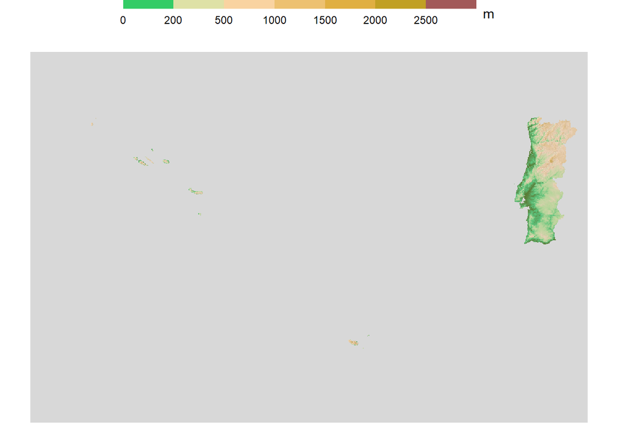

```r
if (!whitebox::check_whitebox_binary()) {
  whitebox::install_whitebox()
}

tif_temp <- here("data", "processed", "mdt_r.tif")
wb_temp <- here("data", "processed", "hillshade_wb.tif")

terra::writeRaster(mdt_r, tif_temp, overwrite = TRUE)
whitebox::wbt_init()
whitebox::wbt_multidirectional_hillshade(tif_temp, wb_temp)

hillwb <- rast(wb_temp) %>%
  mask(vect(pt))
names(hillwb) <- "hillshade"

make_relief_map(hillwb, legend = "top")
```

## Segunda parte: camas hospitalarias en Europa (NUTS-2)

Los datos proceden de Eurostat (`hlth_rs_bdsrg`). Se usa la unidad `P_HTHAB` —**camas por 100.000 habitantes**— y el año 2013, último con cobertura amplia en NUTS-2 dentro de este dataset histórico. Filtrar también `facility == "HBEDT"` evita duplicar regiones con distintos tipos de centro.

```r
ruta_camas <- here("data", "processed", "camas_hospitalarias.rds")
ruta_nuts <- here("data", "processed", "nuts2_2013.rds")

if (!file.exists(ruta_camas) || !file.exists(ruta_nuts)) {
  stop("Faltan datos. Ejecuta: Rscript scripts/fetch_ag3_data.R", call. = FALSE)
}

camas <- read_rds(ruta_camas)
geo_nuts2 <- read_rds(ruta_nuts)

map_data <- geo_nuts2 %>%
  left_join(camas, by = c("id" = "geo"))

stopifnot(!anyDuplicated(map_data$id))
```

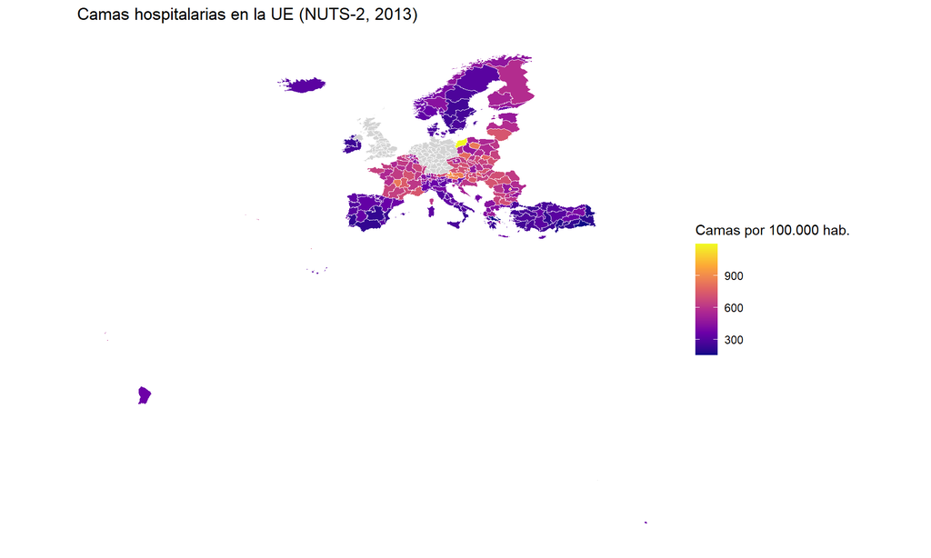

```r
ggplot(map_data) +
  geom_sf(aes(fill = values), color = "white", linewidth = 0.1) +
  scale_fill_viridis_c(
    option = "plasma", na.value = "lightgrey",
    name = "Camas por 100.000 hab."
  ) +
  labs(title = "Camas hospitalarias en la UE (NUTS-2, 2013)") +
  theme_minimal() +
  theme(
    axis.text = element_blank(),
    axis.ticks = element_blank(),
    panel.grid = element_blank()
  )
```

```r
map_data_filtered <- filter(map_data, !is.na(values))
pal <- colorBin("YlOrRd", domain = map_data_filtered$values, bins = 5)

leaflet() %>%
  addTiles() %>%
  addPolygons(
    data = map_data_filtered,
    fillColor = ~ pal(values),
    fillOpacity = 0.6,
    color = "white",
    weight = 1,
    highlight = highlightOptions(weight = 2, color = "#333",
                                 fillOpacity = 0.7)
  ) %>%
  addLegend(
    "bottomright", pal = pal, values = map_data_filtered$values,
    title = "Camas por 100.000 hab.", opacity = 0.7
  )
```

[interactive chart not shown]